# Análisis de los patrones de movilidad residencial en España mediante árboles de clasificación

### Trabajo de Fin de [Máster en Data Science](https://masterdatascience.ifca.es/)

### © Autor: Matin Khakpour

## Capítulo 3: Agregación de bases de datos

Después de haber hecho una aproximación analítica sobre el dataset **EVR 2019** en la fase anterior, ahora pasamos a vincularlo con otros datasets de las principales variables demográficas, censales y territoriales y alimentar el análisis con nuevas variables que nos aportan estas fuentes.

### Revisar los nuevos datasets

(Los ficheros originales de todos los datasets agregados están en el [repositorio](https://github.com/Analytics-Matin/EVR) GitHub del proyecto.)

Los datasets que en principio tenemos pensado usarlos son del *Atlas de distribución de renta de los hogares* del INE, concretamente estos 3 (los ficheros están en la carpeta `AtlasRenta` del repositorio):

1. **Indicadores demográficos**
2. **Indicadores de renta media y mediana**
3. **Distribución por fuente de ingresos**

La última serie de datos disponibles son de los años 2015, 2016 y 2017.

Teníamos los ficheros en formato `xlsx` por lo cual hicimos la parte de preparación en Excel (siguiendo las instrucciones dadas en el Datalab de Ciencias Sociales). A modo de resumen, han sido los siguientes pasos de curación para todos los ficheros:

- Eliminar las líneas extras de cabecera
- Renombrar las variables
- Preparar un diccionario de campos
- Crear dos columnas distintas para ID y Nombre de los municipios, sacando éstos de la columna `ETIQUETA`.
- Sustituir los valores "." con vacío

A continuación vemos el diccionario de campos que hemos creado:

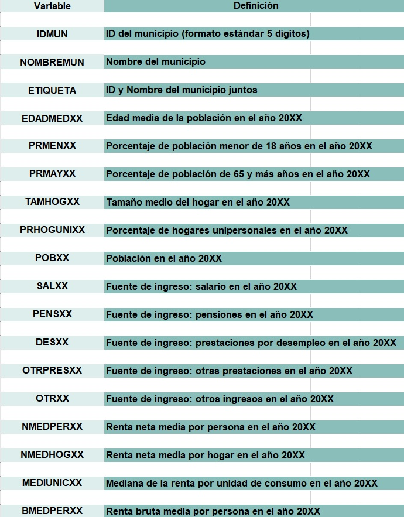

Chequear la cantidad de valores nulos es estos datasets:

```r
library(readxl)
```

```r
demog <- read_excel(choose.files())
```

```r
dim(demog)
```

1. 8131

2. 21

```r
sapply(demog, function(x) sum(is.na(x)))
```

**IDMUN**

0

**NOMBREMUN**

0

**ETIQUETA**

0

**EDADMED17**

1346

**EDADMED16**

1314

**EDADMED15**

1281

**PRMEN17**

1346

**PRMEN16**

1314

**PRMEN15**

1281

**PRMAY17**

1346

**PRMAY16**

1314

**PRMAY15**

1281

**TAMHOG17**

1346

**TAMHOG16**

1314

**TAMHOG15**

1281

**PRHOGUNI17**

1346

**PRHOGUNI16**

1314

**PRHOGUNI15**

1281

**POB17**

1346

**POB16**

1314

**POB15**

1281

```r
ingres <- read_excel(choose.files())
```

```r
dim(ingres)
```

1. 7608

2. 18

```r
sapply(ingres, function(x) sum(is.na(x)))
```

**IDMUN**

0

**NOMBREMUN**

0

**ETIQUETA**

0

**SAL17**

1300

**SAL16**

1271

**SAL15**

1238

**PENS17**

1300

**PENS16**

1271

**PENS15**

1238

**DES17**

1300

**DES16**

1271

**DES15**

1238

**OTRPRES17**

1300

**OTRPRES16**

1271

**OTRPRES15**

1238

**OTR17**

1300

**OTR16**

1271

**OTR15**

1238

```r
renta <- read_excel(choose.files())
```

```r
dim(renta)
```

1. 8131

2. 18

```r
sapply(renta, function(x) sum(is.na(x)))
```

**IDMUN**

0

**NOMBREMUN**

0

**ETIQUETA**

0

**NMEDPER17**

1512

**NMEDPER16**

1319

**NMEDPER15**

1281

**NMEDHOG17**

1512

**NMEDHOG16**

1319

**NMEDHOG15**

1281

**MEDIUNIC17**

1823

**MEDIUNIC16**

1794

**MEDIUNIC15**

1761

**BMEDPER17**

1823

**BMEDPER16**

1794

**BMEDPER15**

1761

**BMEDHOG17**

1823

**BMEDHOG16**

1794

**BMEDHOG15**

1761

Vemos que hay muchos campos con valores nulos. Esto llega a unos 17% de todos los municipios. En algunos casos los nulos son dispersos y en otros casos se concentran en 4 provincias (01-Álava, 20-Gipuzkoa, 48-Bizkaia y 31-Navarra) porque, debido a la estructura tributaria de las provincias forales, algunos de sus datos no están presentes en las tablas del INE.

Primero intentamos sacar esos datos de los institutos de estadística de esas comunidades. Nos damos cuenta de que no tienen los datos para todas las variables que nos faltan en el mismo formato/metodología/periodo.  
Probamos con renta media por persona y por hogar. Estos son los esquemas de los ficheros originales:

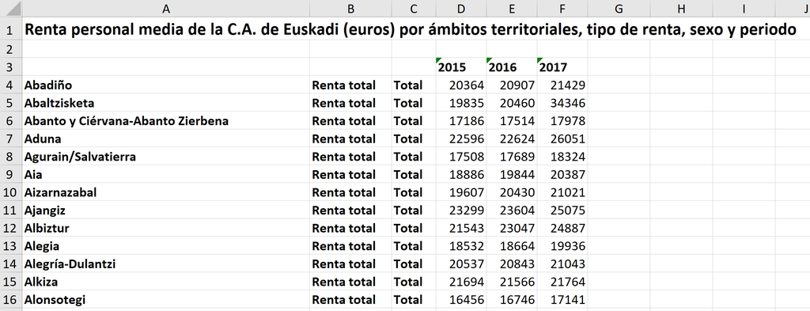

[figure not shown]

Que luego los hemos curado para tener el formato estándar de nuestras tablas:

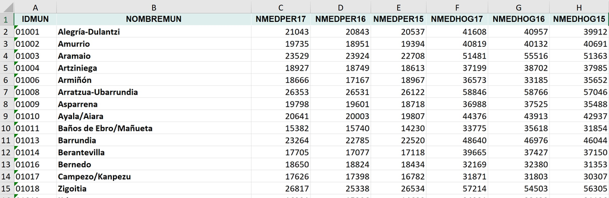

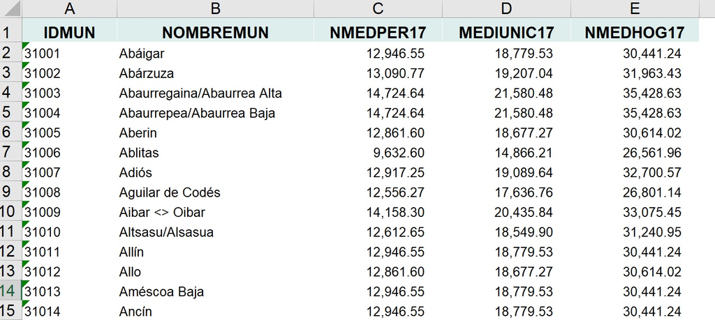

Pero además, nos damos cuenta de que, al parecer, hay una discrepancia entre estas fuentes con los datos del INE.  
Por ejemplo, aquí vemos la renta media por persona de los años 2015-2017 según los datos del INE que se puede observar su diferencia con la tabla de arriba con datos de Euskadi:

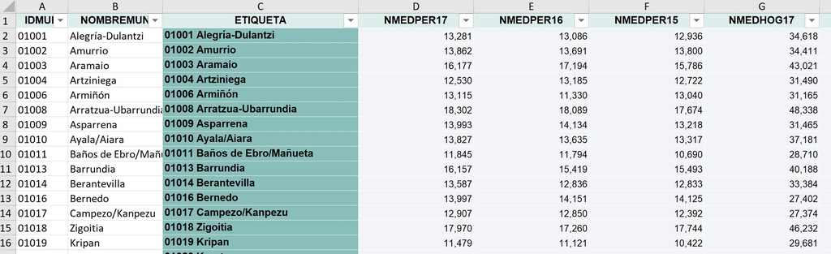

Los de Navarra parecen similares pero les faltan otras variabels del *Atlas*. Entendemos que esto se debe a tener tablas y estructuras diferentes en las fuentes nacionales y regionales, pero esta alteración al final puede afectar a la fiabilidad de nuestro modelo y las conclusiones derivadas.

Teniendo en cuenta que encontrar las equivalencias exactas entre estas fuentes, si es que sea posible, nos puede llevar a un terreno ajeno a nuestra competencia y muy costoso en cuanto al tiempo, al final decidimos no mezclar las fuentes del INE con otras fuentes regionales y descartamos el uso del *Atlas de distribución de renta*.

```r
# limpiar la memoria
rm(demog, ingres, renta)
```

### Revisar otra serie de datasets

Seguimos intentado enlazar EVR con otra serie de ficheros de datos demográficos, territoriales y económicos que hemos sacado de otras tablas del INE durante el Datalab de Ciencias Sociales (los ficheros están en la carpeta `DatalabSS` del repositorio). Cada uno ha sido el resultado de un propio proceso de descarga y curación. En principio tenemos 5 ficheros con datos a nivel municipal:

1. **Evolución de la población**
2. **Estructura demográfica de la población y su dinámica natural**
3. **Datos censales de edificios e inmuebles, hogares y núcleos familiares**
4. **Datos censales de la actividad laboral de personas**
5. **Variables territoriales**

Para darles un uso específico en este TFM tendríamos que curarlos aún más.  
En concreto, hemos realizado estos pasos en Excel:

- Eliminar caracteres especiales (*%) que aprecían en algunas filas posiblemente debido al proceso de anonimización
- Rectificar algunos valores manualmente (por ejemplo, cuando el denominador de un ratio era cero)
- En el caso de las variables que conceptualmente formaban la *Partición de un conjunto* hemos sustituido los nulos con cero, porque tiene sentido (por ejemplo, ramas de actividad laboral)
- Borrar las filas de los municipios para los cuales no había ningún campo con valor relleno (posiblemente debido a los cambios en divisiones territoriales) Han sido escasos.
- Eliminar los registros *condominio de varios municipios* en el dataset de variables territoriales.

Ahora chequeamos los nulos que quedan en los 5 datasets:

### 1. Evolución de la población

```r
evolutivo <- read_excel(choose.files())
```

```r
dim(evolutivo)
```

1. 8131

2. 33

```r
sapply(evolutivo, function(x) sum(is.na(x)))
```

**IDMUN**

0

**CPRO**

0

**PROVINCIA**

0

**CMUN**

0

**NOMBRE**

0

**POB2020**

0

**VAR2020**

0

**MUJ2020**

0

**IMASC20**

0

**POB2016**

8

**VAR2016**

8

**MUJ2016**

8

**IMASC16**

36

**POB2011**

19

**VAR2011**

19

**MUJ2011**

19

**IMASC11**

38

**POB2006**

25

**VAR2006**

25

**MUJ2006**

25

**IMASC06**

38

**POB2001**

28

**VAR2001**

28

**MUJ2001**

28

**IMASC01**

38

**POB1996**

39

**VAR1996**

39

**MUJ1996**

39

**IMASC96**

39

**TC96A06**

39

**TC06A16**

25

**TC16A20**

8

**TC96A20**

39

Usaremos todas las variables del año 2020.  
Para la **Tasa de crecimiento entre 2016 y 2020** hemos chequeado manualmente los 8 municipios con valores nulos. Se tratan de municipios que su división territorial es reciente y resultado de su segregación de otros municipios. Les hemos asignado un valor 0. De todos modos, el efecto de segregación será reflejado en disminución poblacional del municipio padre. Resultado:

```r
sapply(evolutivo, function(x) sum(is.na(x)))
```

**IDMUN**

0

**CPRO**

0

**PROVINCIA**

0

**CMUN**

0

**NOMBRE**

0

**POB2020**

0

**VAR2020**

0

**MUJ2020**

0

**IMASC20**

0

**POB2016**

8

**VAR2016**

8

**MUJ2016**

8

**IMASC16**

36

**POB2011**

19

**VAR2011**

19

**MUJ2011**

19

**IMASC11**

38

**POB2006**

25

**VAR2006**

25

**MUJ2006**

25

**IMASC06**

38

**POB2001**

28

**VAR2001**

28

**MUJ2001**

28

**IMASC01**

38

**POB1996**

39

**VAR1996**

39

**MUJ1996**

39

**IMASC96**

39

**TC96A06**

39

**TC06A16**

25

**TC16A20**

0

**TC96A20**

39

### 2. Estructura demográfica de la población y su dinámica natural

```r
estructura <- read_excel(choose.files())
```

```r
dim(estructura)
```

1. 8131

2. 39

```r
sapply(estructura, function(x) sum(is.na(x)))
```

**IDMUN**

0

**NOMBREMUN**

0

**Etiqueta**

0

**PT2020**

0

**PT0A4**

0

**PT5A9**

0

**PT10A14**

0

**PT15A19**

0

**PT20A24**

0

**PT25A29**

0

**PT30A34**

0

**PT35A39**

0

**PT40A44**

0

**PT45A49**

0

**PT50A54**

0

**PT55A59**

0

**PT60A64**

0

**PT65A69**

0

**PT70A74**

0

**PT75A79**

0

**PT80A84**

0

**PT85A89**

0

**PT90A94**

0

**PT95A99**

0

**PT100YM**

0

**JOVEN**

0

**ADULT**

0

**MAYOR**

0

**PRJOV**

0

**PRAD**

0

**PRMAY**

0

**TDEP**

0

**IDEPJOV**

0

**IDEPMAY**

0

**NACIM**

0

**MUFET**

0

**MATRIM**

0

**FALLEC**

0

**CV**

0

Añadiremos todas sus variables, auqnue según la estructura del modelo decidiremos entrarle todas o algunas. Por ejemplo, en principio, podemos quedarnos con los porcentajes generales de jóvenes, adultos, mayores, etc. Luego si vemos que la variable EDAD es de las principales en el árbol de decisión, usaremos todos los porcentajes de diferentes franjas de edad.

### 3. Datos censales de edificios e inmuebles, hogares y núcleos familiares

```r
edificios <- read_excel(choose.files())
```

```r
dim(edificios)
```

1. 8116

2. 16

```r
sapply(edificios, function(x) sum(is.na(x)))
```

**IDMUN**

0

**Etiqueta**

0

**NOMBREMUN**

0

**EDIFIC**

0

**INMUEB**

0

**RATINEDIF**

0

**VIVFAM**

0

**VIVPRIN**

0

**VIVNOPR**

0

**PRVPRIN**

0

**PRVNPRIN**

0

**TAMEDHOG**

51

**NUCFAM**

182

**NMHIJNUC**

182

**PRMONOPAR**

182

**PRNUMEROS**

182

Usaremos todas las variables sin nulo.  
Si vemos que algunas de las variables de este dataset tienen mucho peso decisivo en la salida del modelo, podremos volver y asignar valores a los 182 municipios nulos según - por ejemplo - el promedio de la provincia correspondiente.

### 4. Datos censales de la actividad laboral de personas

```r
ocupados <- read_excel(choose.files())
```

```r
dim(ocupados)
```

1. 8116

2. 20

```r
sapply(ocupados, function(x) sum(is.na(x)))
```

**IDMUN**

0

**ETIQUETA**

0

**NOMBREMUN**

0

**OCTC**

0

**OCTP**

0

**PARTA**

0

**PARPE**

0

**INVPERM**

0

**JUBPENS**

0

**ESTUD**

0

**OCUOTR**

0

**PRIMARIO**

0

**CONSTRU**

0

**INDUSTR**

0

**NOAPLI**

0

**SERVICIOS**

0

**TOTRAMAS**

0

**PRPRIM**

326

**PRSEC**

326

**PRSERVIC**

326

Usaremos todas las variables sin nulo.  
Los nulos de las últimas tres variables son errores derivados de división con denominador cero (TOTAL RAMAS = 0 porque solo tienen registros en NO APLICABLE). Entonces los hemos sustituido por cero y ya podremos usar todas. Resultado:

```r
sapply(ocupados, function(x) sum(is.na(x)))
```

**IDMUN**

0

**ETIQUETA**

0

**NOMBREMUN**

0

**OCTC**

0

**OCTP**

0

**PARTA**

0

**PARPE**

0

**INVPERM**

0

**JUBPENS**

0

**ESTUD**

0

**OCUOTR**

0

**PRIMARIO**

0

**CONSTRU**

0

**INDUSTR**

0

**NOAPLI**

0

**SERVICIOS**

0

**TOTRAMAS**

0

**PRPRIM**

0

**PRSEC**

0

**PRSERVIC**

0

### 5. Variables territoriales

```r
territorial <- read_excel(choose.files())
```

```r
sapply(territorial, function(x) sum(is.na(x)))
```

**IDMUN**

0

**POB2020**

0

**CPRO**

0

**ETIQUETA**

0

**AREAKM2**

0

**PENDIENTE_GRADOS**

0

**ALTITUD_M**

0

**DISTNUC10KM_M**

0

**DISTAUTOPAUTOV_M**

0

**DISTCARRNAC_M**

0

**DISTESTACFERROC_M**

0

Usaremos todas las variables territoriales.

### Preparar y delimitar el dataset EVR

Hacemos un subconjunto para enfocar nuestro análisis en **todos los cambios residenciales cuyos ambos municipios de origen y de destino son del territorio español**.

```r
db <- readr::read_tsv(choose.files())  # cargar el fichero "db_fase1.tsv"
                                       # de la fase anterior
```

```r
dim(db)
```

1. 2868942

2. 16

Crear el subset de movimientos a nivel nacional:

```r
db <- subset(db, (PROVALTA != "66" & PROVBAJA != "66"))
```

```r
dim(db)
```

1. 1649351

2. 16

Descartamos algunas variables que no son relevantes:

- Mes de nacimiento
- Año de nacimiento (ya que tenemos la edad)
- Año de variación (es igual para todos los registros de un fichero anual)

```r
db$MESNAC <- NULL
db$ANONAC <- NULL
db$ANOVAR <- NULL
```

En el caso de código de nacionalidad, la convertimos en variable binaria (0 para española y 1 para extranjera):

```r
db$CNAC <- factor(ifelse(db$CNAC == 108, 0, 1))
```

```r
table(db$CNAC)
```

```
      0       1
1240566  408785
```

Hacemos algo similar sobre el lugar de nacimiento (0 en España y 1 en extranjero), pero añadiéndola como una variable nueva (**B**PROVNAC) porque luego necesitamos PROVNAC para otro procedimiento:

```r
db$BPROVNAC <- factor(ifelse(db$PROVNAC == 66, 1, 0))
```

```r
table(db$BPROVNAC)
```

```
      0       1
1146640  502711
```

Chequeamos los nulos que existen:

```r
sapply(db, function(x) sum(is.na(x)))
```

**SEXO**

0

**PROVNAC**

0

**MUNINAC**

212266

**EDAD**

0

**CNAC**

0

**PROVALTA**

0

**MUNIALTA**

397718

**MESVAR**

0

**PROVBAJA**

0

**MUNIBAJA**

383643

**TAMUALTA**

0

**TAMUBAJA**

0

**TAMUNACI**

502711

**BPROVNAC**

0

El TAMUNACI es nulo para todos los nacidos en extranjero. En el modelo que tenemos pensado, de momento, no lo incluiremos pero, si en algún momento hacemo otro subset solo con los nacidos en España podremos incluirlo. Así verificamos que en ese caso no tendrá nulos:

```r
sapply(db[db$BPROVNAC == 0,], function(x) sum(is.na(x)))
```

**SEXO**

0

**PROVNAC**

0

**MUNINAC**

212266

**EDAD**

0

**CNAC**

0

**PROVALTA**

0

**MUNIALTA**

300311

**MESVAR**

0

**PROVBAJA**

0

**MUNIBAJA**

292694

**TAMUALTA**

0

**TAMUBAJA**

0

**TAMUNACI**

0

**BPROVNAC**

0

Tenemos que generar nuevos campos ID para municipios de ALTA y BAJA, concatenando sus correspondientes códigos de provincia y de municipio para llegar a tener el código municipal estándar de 5 dígitos.

```r
db$MUNIALTA[is.na(db$MUNIALTA)] <- "999"

db$MUNIBAJA[is.na(db$MUNIBAJA)] <- "999"
```

Ahora podemos concatenar todos los códigos provinciales y municipales:

```r
db$IDMUNIALTA <- paste(db$PROVALTA, db$MUNIALTA, sep="")
```

```r
db$IDMUNIBAJA <- paste(db$PROVBAJA, db$MUNIBAJA, sep="")
```

Creamos dos **escala de arraigo/distancia** para medir la cercanía entre la provincia de nacimiento y la provincia de alta o baja:

**ARRALTA**:

- 1 -> PROVNAC = PROVALTA (nacido en España)
- 2 -> PROVNAC != PROVALTA (nacido en España)
- 3 -> ninguno de los anteriores (nacido en extranjero)

**ARRBAJA**:

- 1 -> PROVNAC = PROVBAJA (nacido en España)
- 2 -> PROVNAC != PROVBAJA (nacido en España)
- 3 -> ninguno de los anteriores (nacido en extranjero)

```r
db$ARRALTA <- NA
db$ARRBAJA <- NA
```

```r
naci_esp <- db$BPROVNAC == 0

db$ARRALTA[naci_esp] <- factor(ifelse(db$PROVNAC[naci_esp] == db$PROVALTA[naci_esp], 1, 2))

db$ARRBAJA[naci_esp] <- factor(ifelse(db$PROVNAC[naci_esp] == db$PROVBAJA[naci_esp], 1, 2))
```

```r
naci_ext <- db$BPROVNAC == 1

db$ARRALTA[naci_ext] <- 3

db$ARRBAJA[naci_ext] <- 3
```

Reordenamos las columnas para tener mejor legibilidad:

```r
db <- db[c("SEXO","EDAD","MESVAR","CNAC","BPROVNAC","PROVNAC","MUNINAC","TAMUNACI","PROVALTA","MUNIALTA","IDMUNIALTA","TAMUALTA","ARRALTA","PROVBAJA","MUNIBAJA","IDMUNIBAJA","TAMUBAJA","ARRBAJA")]
```

```r
head(db)
```

| SEXO | EDAD | MESVAR | CNAC | BPROVNAC | PROVNAC | MUNINAC | TAMUNACI | PROVALTA | MUNIALTA | IDMUNIALTA | TAMUALTA | ARRALTA | PROVBAJA | MUNIBAJA | IDMUNIBAJA | TAMUBAJA | ARRBAJA |
| --- | --- | --- | --- | --- | --- | --- | --- | --- | --- | --- | --- | --- | --- | --- | --- | --- | --- |
| V | 4 | 7 | 0 | 0 | 01 | NA | 1 | 01 | 999 | 01999 | 1 | 1 | 01 | 999 | 01999 | 1 | 1 |
| M | 1 | 7 | 0 | 0 | 01 | NA | 1 | 01 | 999 | 01999 | 1 | 1 | 01 | 999 | 01999 | 1 | 1 |
| V | 36 | 3 | 0 | 0 | 01 | NA | 1 | 01 | 999 | 01999 | 1 | 1 | 01 | 999 | 01999 | 1 | 1 |
| V | 26 | 5 | 0 | 0 | 01 | NA | 1 | 01 | 059 | 01059 | 6 | 1 | 01 | 999 | 01999 | 1 | 1 |
| M | 37 | 6 | 0 | 0 | 01 | NA | 1 | 01 | 059 | 01059 | 6 | 1 | 01 | 999 | 01999 | 1 | 1 |
| M | 75 | 1 | 0 | 0 | 01 | NA | 1 | 01 | 059 | 01059 | 6 | 1 | 01 | 999 | 01999 | 1 | 1 |

Antes de añadir otras variables, guardamos una copia de esta versión editada de EVR:

```r
write.table(db, file = "EVR(fase2).tsv", row.names=FALSE, sep="\t")
```

### Preparar los nuevos datasets

A los 5 ficheros nuevos que queremos enlazarlos con EVR tenemos que agregar una fila por cada provincia con el fuzzy ID que representa el municipio poco-poblado ejemplar. Luego, asignar un valor apropiado de cada variable para este minicipio imaginario no es trivial. Optamos por asignarle el *promedio de los valores de los municipios con menos de 10,000 habitantes en la misma provincia*. En el caso de métricas cardinales hay que convertir la media a un número entero.

### 1. Evolución de la población

```r
names(evolutivo)
```

1. 'IDMUN'

2. 'CPRO'

3. 'PROVINCIA'

4. 'CMUN'

5. 'NOMBRE'

6. 'POB2020'

7. 'VAR2020'

8. 'MUJ2020'

9. 'IMASC20'

10. 'POB2016'

11. 'VAR2016'

12. 'MUJ2016'

13. 'IMASC16'

14. 'POB2011'

15. 'VAR2011'

16. 'MUJ2011'

17. 'IMASC11'

18. 'POB2006'

19. 'VAR2006'

20. 'MUJ2006'

21. 'IMASC06'

22. 'POB2001'

23. 'VAR2001'

24. 'MUJ2001'

25. 'IMASC01'

26. 'POB1996'

27. 'VAR1996'

28. 'MUJ1996'

29. 'IMASC96'

30. 'TC96A06'

31. 'TC06A16'

32. 'TC16A20'

33. 'TC96A20'

(Para estos *workarounds* apartamos los IDMUN 51001 y 52001 (Ceuta y Melilla), porque solo tienen un municipio que a su vez tiene una población mayor a 10,000. Entonces no necesitan fuzzy municipio.)

```r
provincias <- names(table(evolutivo$CPRO))[1:50] # provincias desde 01 hasta 50

for(prov in provincias){

    sub_prov <- evolutivo[evolutivo$CPRO == prov,] # subset por provincia

    sub_peq <- sub_prov[sub_prov$POB2020 <= 10000,] # subset por municipios pequeños

    pob <- round(mean(sub_peq$POB2020)) # calcular las métricas
    var <- round(mean(sub_peq$VAR2020))
    muj <- round(mean(sub_peq$MUJ2020))

    imasc <- mean(sub_peq$IMASC20)

    tc <- mean(sub_peq$TC16A20)

    fuzzy_mun <- data.frame(IDMUN = paste(prov,999,sep=""),
                            CPRO = prov,
                            POB2020 = pob,
                            VAR2020 = var,
                            MUJ2020 = muj,
                            IMASC20 = imasc,
                            TC16A20 = tc)                  # agrupar los campos

    evolutivo <- dplyr::bind_rows(evolutivo, fuzzy_mun) # añadir la fila nueva al dataset
}
```

Podemos ver estas filas añadidas al final del dataset:

```r
tail(evolutivo)
```

| IDMUN | CPRO | PROVINCIA | CMUN | NOMBRE | POB2020 | VAR2020 | MUJ2020 | IMASC20 | POB2016 | ... | MUJ2001 | IMASC01 | POB1996 | VAR1996 | MUJ1996 | IMASC96 | TC96A06 | TC06A16 | TC16A20 | TC96A20 |
| --- | --- | --- | --- | --- | --- | --- | --- | --- | --- | --- | --- | --- | --- | --- | --- | --- | --- | --- | --- | --- |
| 45999 | 45 | NA | NA | NA | 2006 | 1028 | 978 | 108.2655 | NA | ... | NA | NA | NA | NA | NA | NA | NA | NA | -0.7330589 | NA |
| 46999 | 46 | NA | NA | NA | 2214 | 1114 | 1100 | 105.4202 | NA | ... | NA | NA | NA | NA | NA | NA | NA | NA | -0.2478419 | NA |
| 47999 | 47 | NA | NA | NA | 713 | 370 | 344 | 122.2334 | NA | ... | NA | NA | NA | NA | NA | NA | NA | NA | -1.2919373 | NA |
| 48999 | 48 | NA | NA | NA | 2356 | 1174 | 1183 | 103.2748 | NA | ... | NA | NA | NA | NA | NA | NA | NA | NA | 0.0485536 | NA |
| 49999 | 49 | NA | NA | NA | 373 | 193 | 180 | 112.4926 | NA | ... | NA | NA | NA | NA | NA | NA | NA | NA | -2.1101971 | NA |
| 50999 | 50 | NA | NA | NA | 702 | 364 | 338 | 122.8559 | NA | ... | NA | NA | NA | NA | NA | NA | NA | NA | -1.0570176 | NA |

Ahora podemos escoger solo las columnas que queremos usar:

```r
evolutivo <- evolutivo[c("IDMUN","POB2020","VAR2020","MUJ2020","IMASC20","TC16A20")]
```

```r
tail(evolutivo)
```

| IDMUN | POB2020 | VAR2020 | MUJ2020 | IMASC20 | TC16A20 |
| --- | --- | --- | --- | --- | --- |
| 45999 | 2006 | 1028 | 978 | 108.2655 | -0.7330589 |
| 46999 | 2214 | 1114 | 1100 | 105.4202 | -0.2478419 |
| 47999 | 713 | 370 | 344 | 122.2334 | -1.2919373 |
| 48999 | 2356 | 1174 | 1183 | 103.2748 | 0.0485536 |
| 49999 | 373 | 193 | 180 | 112.4926 | -2.1101971 |
| 50999 | 702 | 364 | 338 | 122.8559 | -1.0570176 |

Debemos repetir el mismo procedimiento para los demás datasets.

Pero nos damos cuenta cuenta de que necesitamos añadir dos columnas CPRO y POB2020 a todos los demás datasets que carecen de estas variables, porque luego las necesitaremos para hacer el subset y calcular las métricas de municipios pequeños.

Resulta que el número total de municipios en estos datasets es un poco diferente. Entonces tuvimos que tomar como referencia el dataset de EVOLUTIVOS y corregir los registros no-coincidentes (unos 30 casos). Para algunos hemos buscado la población directamente en las tablas de INE o los portales de la Comunidad Autónoma correspondiente y en otros casos que descubrimos que son municipios desaparecidos ya desde hace unos años debido a las nuevas divisiones y segregaciones territoriales, hemos borrado el registro.

Después sí podemos aplicar el proceso a otros datasets:

### 2. Estructura demográfica de la población y su dinámica natural

```r
names(estructura)
```

1. 'IDMUN'

2. 'CPRO'

3. 'POB2020'

4. 'NOMBREMUN'

5. 'Etiqueta'

6. 'PT2020'

7. 'PT0A4'

8. 'PT5A9'

9. 'PT10A14'

10. 'PT15A19'

11. 'PT20A24'

12. 'PT25A29'

13. 'PT30A34'

14. 'PT35A39'

15. 'PT40A44'

16. 'PT45A49'

17. 'PT50A54'

18. 'PT55A59'

19. 'PT60A64'

20. 'PT65A69'

21. 'PT70A74'

22. 'PT75A79'

23. 'PT80A84'

24. 'PT85A89'

25. 'PT90A94'

26. 'PT95A99'

27. 'PT100YM'

28. 'JOVEN'

29. 'ADULT'

30. 'MAYOR'

31. 'PRJOV'

32. 'PRAD'

33. 'PRMAY'

34. 'TDEP'

35. 'IDEPJOV'

36. 'IDEPMAY'

37. 'NACIM'

38. 'MUFET'

39. 'MATRIM'

40. 'FALLEC'

41. 'CV'

```r
provincias <- names(table(estructura$CPRO))[1:50] # provincias desde 01 hasta 50

for(prov in provincias){

    sub_prov <- estructura[estructura$CPRO == prov,] # subset por provincia

    sub_peq <- sub_prov[sub_prov$POB2020 <= 10000,] # subset por municipios pequeños

    pt1 <- round(mean(sub_peq$PT0A4)) # calcular las métricas
    pt2 <- round(mean(sub_peq$PT5A9))
    pt3 <- round(mean(sub_peq$PT10A14))
    pt4 <- round(mean(sub_peq$PT15A19))
    pt5 <- round(mean(sub_peq$PT15A19))
    pt6 <- round(mean(sub_peq$PT20A24))
    pt7 <- round(mean(sub_peq$PT25A29))
    pt8 <- round(mean(sub_peq$PT30A34))
    pt9 <- round(mean(sub_peq$PT35A39))
    pt10 <- round(mean(sub_peq$PT40A44))
    pt11 <- round(mean(sub_peq$PT45A49))
    pt12 <- round(mean(sub_peq$PT50A54))
    pt13 <- round(mean(sub_peq$PT55A59))
    pt14 <- round(mean(sub_peq$PT60A64))
    pt15 <- round(mean(sub_peq$PT65A69))
    pt16 <- round(mean(sub_peq$PT70A74))
    pt17 <- round(mean(sub_peq$PT75A79))
    pt18 <- round(mean(sub_peq$PT80A84))
    pt19 <- round(mean(sub_peq$PT85A89))
    pt20 <- round(mean(sub_peq$PT90A94))
    pt21 <- round(mean(sub_peq$PT95A99))
    pt22 <- round(mean(sub_peq$PT100YM))

    jov <- round(mean(sub_peq$JOVEN))
    ad <- round(mean(sub_peq$ADULT))
    may <- round(mean(sub_peq$MAYOR))

    prjov <- mean(sub_peq$PRJOV)
    prad <- mean(sub_peq$PRAD)
    prmay <- mean(sub_peq$PRMAY)
    tdep <- mean(sub_peq$TDEP)
    idepjov <- mean(sub_peq$IDEPJOV)
    idepmay <- mean(sub_peq$IDEPMAY)

    nacim <- round(mean(sub_peq$NACIM))
    mufet <- round(mean(sub_peq$MUFET))
    matrim <- round(mean(sub_peq$MATRIM))
    fallec <- round(mean(sub_peq$FALLEC))
    cv <- round(mean(sub_peq$CV))


    fuzzy_mun <- data.frame(IDMUN = paste(prov,999,sep=""),
                            CPRO = prov,

                            PT0A4 = pt1,
                            PT5A9 = pt2,
                            PT10A14 = pt3,
                            PT15A19 = pt4,
                            PT20A24 = pt5,
                            PT25A29 = pt6,
                            PT30A34 = pt7,
                            PT35A39 = pt8,
                            PT40A44 = pt9,
                            PT45A49 = pt10,
                            PT50A54 = pt11,
                            PT55A59 = pt12,
                            PT60A64 = pt13,
                            PT65A69 = pt14,
                            PT70A74 = pt15,
                            PT75A79 = pt16,
                            PT80A84 = pt17,
                            PT85A89 = pt19,
                            PT90A94 = pt20,
                            PT95A99 = pt21,
                            PT100YM = pt22,

                            JOVEN = jov,
                            ADULT = ad,
                            MAYOR = may,

                            PRJOV = prjov,
                            PRAD = prad,
                            PRMAY = prmay,
                            TDEP = tdep,
                            IDEPJOV = idepjov,
                            IDEPMAY = idepmay,

                            NACIM = nacim,
                            MUFET = mufet,
                            MATRIM = matrim,
                            FALLEC = fallec,
                            CV = cv)                  # agrupar los campos

    estructura <- dplyr::bind_rows(estructura, fuzzy_mun) # añadir la fila nueva al dataset
}
```

```r
tail(estructura)
```

| IDMUN | CPRO | POB2020 | NOMBREMUN | Etiqueta | PT2020 | PT0A4 | PT5A9 | PT10A14 | PT15A19 | ... | PRAD | PRMAY | TDEP | IDEPJOV | IDEPMAY | NACIM | MUFET | MATRIM | FALLEC | CV |
| --- | --- | --- | --- | --- | --- | --- | --- | --- | --- | --- | --- | --- | --- | --- | --- | --- | --- | --- | --- | --- |
| 45999 | 45 | NA | NA | NA | NA | 82 | 103 | 115 | 105 | ... | 61.17561 | 27.04803 | 66.70827 | 18.716439 | 47.99183 | 15 | 0 | 7 | 21 | -6 |
| 46999 | 46 | NA | NA | NA | NA | 86 | 110 | 119 | 108 | ... | 64.47919 | 23.27572 | 55.71811 | 18.907014 | 36.81110 | 16 | 0 | 8 | 22 | -7 |
| 47999 | 47 | NA | NA | NA | NA | 26 | 34 | 36 | 31 | ... | 59.53957 | 33.67312 | 70.95510 | 11.211214 | 59.74389 | 5 | 0 | 2 | 7 | -3 |
| 48999 | 48 | NA | NA | NA | NA | 95 | 119 | 122 | 114 | ... | 64.43824 | 21.62607 | 55.50481 | 21.685490 | 33.81932 | 17 | 0 | 7 | 23 | -7 |
| 49999 | 49 | NA | NA | NA | NA | 8 | 9 | 10 | 11 | ... | 52.69816 | 42.53347 | 93.59357 | 8.780145 | 84.81342 | 2 | 0 | 1 | 8 | -6 |
| 50999 | 50 | NA | NA | NA | NA | 26 | 32 | 34 | 32 | ... | 58.95102 | 33.79378 | 72.16054 | 12.060060 | 60.10048 | 5 | 0 | 2 | 9 | -4 |

```r
estructura <- estructura[c(1,7:ncol(estructura))]
```

```r
tail(estructura)
```

| IDMUN | PT0A4 | PT5A9 | PT10A14 | PT15A19 | PT20A24 | PT25A29 | PT30A34 | PT35A39 | PT40A44 | ... | PRAD | PRMAY | TDEP | IDEPJOV | IDEPMAY | NACIM | MUFET | MATRIM | FALLEC | CV |
| --- | --- | --- | --- | --- | --- | --- | --- | --- | --- | --- | --- | --- | --- | --- | --- | --- | --- | --- | --- | --- |
| 45999 | 82 | 103 | 115 | 105 | 105 | 99 | 101 | 114 | 143 | ... | 61.17561 | 27.04803 | 66.70827 | 18.716439 | 47.99183 | 15 | 0 | 7 | 21 | -6 |
| 46999 | 86 | 110 | 119 | 108 | 108 | 103 | 109 | 122 | 159 | ... | 64.47919 | 23.27572 | 55.71811 | 18.907014 | 36.81110 | 16 | 0 | 8 | 22 | -7 |
| 47999 | 26 | 34 | 36 | 31 | 31 | 29 | 31 | 37 | 50 | ... | 59.53957 | 33.67312 | 70.95510 | 11.211214 | 59.74389 | 5 | 0 | 2 | 7 | -3 |
| 48999 | 95 | 119 | 122 | 114 | 114 | 96 | 98 | 115 | 154 | ... | 64.43824 | 21.62607 | 55.50481 | 21.685490 | 33.81932 | 17 | 0 | 7 | 23 | -7 |
| 49999 | 8 | 9 | 10 | 11 | 11 | 13 | 15 | 17 | 20 | ... | 52.69816 | 42.53347 | 93.59357 | 8.780145 | 84.81342 | 2 | 0 | 1 | 8 | -6 |
| 50999 | 26 | 32 | 34 | 32 | 32 | 32 | 34 | 40 | 47 | ... | 58.95102 | 33.79378 | 72.16054 | 12.060060 | 60.10048 | 5 | 0 | 2 | 9 | -4 |

### 3. Datos censales de edificios e inmuebles, hogares y núcleos familiares

```r
names(edificios)
```

1. 'IDMUN'

2. 'POB2020'

3. 'CPRO'

4. 'Etiqueta'

5. 'NOMBREMUN'

6. 'EDIFIC'

7. 'INMUEB'

8. 'RATINEDIF'

9. 'VIVFAM'

10. 'VIVPRIN'

11. 'VIVNOPR'

12. 'PRVPRIN'

13. 'PRVNPRIN'

14. 'TAMEDHOG'

15. 'NUCFAM'

16. 'NMHIJNUC'

17. 'PRMONOPAR'

18. 'PRNUMEROS'

```r
provincias <- names(table(edificios$CPRO))[1:50] # provincias desde 01 hasta 50

for(prov in provincias){

    sub_prov <- edificios[edificios$CPRO == prov,] # subset por provincia

    sub_peq <- sub_prov[sub_prov$POB2020 <= 10000,] # subset por municipios pequeños

    edific <- round(mean(sub_peq$EDIFIC)) # calcular las métricas
    inmueb <- round(mean(sub_peq$INMUEB))

    ratinedif <- mean(sub_peq$RATINEDIF)

    vivfam <- round(mean(sub_peq$VIVFAM))
    vivprin <- round(mean(sub_peq$VIVPRIN))
    vivnopr <- round(mean(sub_peq$VIVNOPR))

    prvprin <- mean(sub_peq$PRVPRIN)
    prvnprin <- mean(sub_peq$PRVNPRIN)


    fuzzy_mun <- data.frame(IDMUN = paste(prov,999,sep=""),
                            CPRO = prov,

                            EDIFIC = edific,
                            INMUEB = inmueb,

                            RATINEDIF = ratinedif,

                            VIVFAM = vivfam,
                            VIVPRIN = vivprin,
                            VIVNOPR = vivnopr,

                            PRVPRIN = prvprin,
                            PRVNPRIN = prvnprin
                           )                  # agrupar los campos

    edificios <- dplyr::bind_rows(edificios, fuzzy_mun) # añadir la fila nueva al dataset
}
```

```r
tail(edificios)
```

| IDMUN | POB2020 | CPRO | Etiqueta | NOMBREMUN | EDIFIC | INMUEB | RATINEDIF | VIVFAM | VIVPRIN | VIVNOPR | PRVPRIN | PRVNPRIN | TAMEDHOG | NUCFAM | NMHIJNUC | PRMONOPAR | PRNUMEROS |
| --- | --- | --- | --- | --- | --- | --- | --- | --- | --- | --- | --- | --- | --- | --- | --- | --- | --- |
| 45999 | NA | 45 | NA | NA | 1149 | 1389 | 1.168655 | 1371 | 766 | 605 | 51.83762 | 48.16238 | NA | NA | NA | NA | NA |
| 46999 | NA | 46 | NA | NA | 869 | 1516 | 1.598088 | 1480 | 867 | 612 | 60.25983 | 39.74017 | NA | NA | NA | NA | NA |
| 47999 | NA | 47 | NA | NA | 362 | 460 | 1.090089 | 453 | 287 | 166 | 56.61304 | 43.38696 | NA | NA | NA | NA | NA |
| 48999 | NA | 48 | NA | NA | 397 | 1346 | 2.939766 | 1195 | 905 | 289 | 74.32750 | 25.67250 | NA | NA | NA | NA | NA |
| 49999 | NA | 49 | NA | NA | 329 | 363 | 1.046146 | 359 | 182 | 177 | 50.79546 | 49.20454 | NA | NA | NA | NA | NA |
| 50999 | NA | 50 | NA | NA | 365 | 489 | 1.172054 | 480 | 289 | 191 | 49.08445 | 50.91555 | NA | NA | NA | NA | NA |

```r
edificios <- edificios[c(1,6:13)]
```

```r
tail(edificios)
```

| IDMUN | EDIFIC | INMUEB | RATINEDIF | VIVFAM | VIVPRIN | VIVNOPR | PRVPRIN | PRVNPRIN |
| --- | --- | --- | --- | --- | --- | --- | --- | --- |
| 45999 | 1149 | 1389 | 1.168655 | 1371 | 766 | 605 | 51.83762 | 48.16238 |
| 46999 | 869 | 1516 | 1.598088 | 1480 | 867 | 612 | 60.25983 | 39.74017 |
| 47999 | 362 | 460 | 1.090089 | 453 | 287 | 166 | 56.61304 | 43.38696 |
| 48999 | 397 | 1346 | 2.939766 | 1195 | 905 | 289 | 74.32750 | 25.67250 |
| 49999 | 329 | 363 | 1.046146 | 359 | 182 | 177 | 50.79546 | 49.20454 |
| 50999 | 365 | 489 | 1.172054 | 480 | 289 | 191 | 49.08445 | 50.91555 |

### 4. Datos censales de la actividad laboral de personas

```r
names(ocupados)
```

1. 'IDMUN'

2. 'POB2020'

3. 'CPRO'

4. 'ETIQUETA'

5. 'NOMBREMUN'

6. 'OCTC'

7. 'OCTP'

8. 'PARTA'

9. 'PARPE'

10. 'INVPERM'

11. 'JUBPENS'

12. 'ESTUD'

13. 'OCUOTR'

14. 'PRIMARIO'

15. 'CONSTRU'

16. 'INDUSTR'

17. 'NOAPLI'

18. 'SERVICIOS'

19. 'TOTRAMAS'

20. 'PRPRIM'

21. 'PRSEC'

22. 'PRSERVIC'

```r
provincias <- names(table(ocupados$CPRO))[1:50] # provincias desde 01 hasta 50

for(prov in provincias){

    sub_prov <- ocupados[ocupados$CPRO == prov,] # subset por provincia

    sub_peq <- sub_prov[sub_prov$POB2020 <= 10000,] # subset por municipios pequeños

    octc <- round(mean(sub_peq$OCTC)) # calcular las métricas
    octp <- round(mean(sub_peq$OCTP))
    parta <- round(mean(sub_peq$PARTA))
    parpe <- round(mean(sub_peq$PARPE))
    invperm <- round(mean(sub_peq$INVPERM))
    jubpens <- round(mean(sub_peq$JUBPENS))
    estud <- round(mean(sub_peq$ESTUD))
    ocuotr <- round(mean(sub_peq$OCUOTR))
    primario <- round(mean(sub_peq$PRIMARIO))
    constru <- round(mean(sub_peq$CONSTRU))
    industr <- round(mean(sub_peq$INDUSTR))
    noapli <- round(mean(sub_peq$NOAPLI))
    servicios <- round(mean(sub_peq$SERVICIOS))
    totramas <- round(mean(sub_peq$TOTRAMAS))

    prprim <- mean(sub_peq$PRPRIM)
    prsec <- mean(sub_peq$PRSEC)
    prservic <- mean(sub_peq$PRSERVIC)


    fuzzy_mun <- data.frame(IDMUN = paste(prov,999,sep=""),
                            CPRO = prov,

                            OCTC = octc,
                            OCTP = octp,
                            PARTA = parta,
                            PARPE = parpe,
                            INVPERM = invperm,
                            JUBPENS = jubpens,
                            ESTUD = estud,
                            OCUOTR = ocuotr,
                            PRIMARIO = primario,
                            CONSTRU = constru,
                            INDUSTR = industr,
                            NOAPLI = noapli,
                            SERVICIOS = servicios,
                            TOTRAMAS = totramas,

                            PRPRIM = prprim,
                            PRSEC = prsec,
                            PRSERVIC = prservic
                           )                  # agrupar los campos

    ocupados <- dplyr::bind_rows(ocupados, fuzzy_mun) # añadir la fila nueva al dataset
}
```

```r
tail(ocupados)
```

| IDMUN | POB2020 | CPRO | ETIQUETA | NOMBREMUN | OCTC | OCTP | PARTA | PARPE | INVPERM | ... | OCUOTR | PRIMARIO | CONSTRU | INDUSTR | NOAPLI | SERVICIOS | TOTRAMAS | PRPRIM | PRSEC | PRSERVIC |
| --- | --- | --- | --- | --- | --- | --- | --- | --- | --- | --- | --- | --- | --- | --- | --- | --- | --- | --- | --- | --- |
| 45999 | NA | 45 | NA | NA | 600 | 91 | 334 | 45 | 14 | ... | 191 | 59 | 175 | 181 | 1043 | 605 | 1021 | 8.523544 | 32.04606 | 58.90956 |
| 46999 | NA | 46 | NA | NA | 686 | 133 | 315 | 38 | 30 | ... | 148 | 90 | 129 | 225 | 1079 | 687 | 1131 | 9.730101 | 30.60318 | 59.66672 |
| 47999 | NA | 47 | NA | NA | 255 | 39 | 86 | 8 | 3 | ... | 65 | 42 | 45 | 61 | 343 | 229 | 378 | 26.603977 | 17.12091 | 51.75023 |
| 48999 | NA | 48 | NA | NA | 816 | 142 | 213 | 35 | 30 | ... | 177 | 27 | 101 | 276 | 1133 | 759 | 1164 | 2.490550 | 31.79274 | 65.71671 |
| 49999 | NA | 49 | NA | NA | 118 | 14 | 47 | 4 | 2 | ... | 38 | 32 | 30 | 20 | 248 | 96 | 178 | 24.245812 | 23.08092 | 51.45375 |
| 50999 | NA | 50 | NA | NA | 243 | 39 | 79 | 8 | 5 | ... | 56 | 42 | 37 | 87 | 361 | 193 | 359 | 15.968508 | 24.27468 | 51.71486 |

```r
ocupados <- ocupados[c(1,6:ncol(ocupados))]
```

```r
tail(ocupados)
```

| IDMUN | OCTC | OCTP | PARTA | PARPE | INVPERM | JUBPENS | ESTUD | OCUOTR | PRIMARIO | CONSTRU | INDUSTR | NOAPLI | SERVICIOS | TOTRAMAS | PRPRIM | PRSEC | PRSERVIC |
| --- | --- | --- | --- | --- | --- | --- | --- | --- | --- | --- | --- | --- | --- | --- | --- | --- | --- |
| 45999 | 600 | 91 | 334 | 45 | 14 | 398 | 385 | 191 | 59 | 175 | 181 | 1043 | 605 | 1021 | 8.523544 | 32.04606 | 58.90956 |
| 46999 | 686 | 133 | 315 | 38 | 30 | 447 | 405 | 148 | 90 | 129 | 225 | 1079 | 687 | 1131 | 9.730101 | 30.60318 | 59.66672 |
| 47999 | 255 | 39 | 86 | 8 | 3 | 141 | 119 | 65 | 42 | 45 | 61 | 343 | 229 | 378 | 26.603977 | 17.12091 | 51.75023 |
| 48999 | 816 | 142 | 213 | 35 | 30 | 476 | 406 | 177 | 27 | 101 | 276 | 1133 | 759 | 1164 | 2.490550 | 31.79274 | 65.71671 |
| 49999 | 118 | 14 | 47 | 4 | 2 | 149 | 46 | 38 | 32 | 30 | 20 | 248 | 96 | 178 | 24.245812 | 23.08092 | 51.45375 |
| 50999 | 243 | 39 | 79 | 8 | 5 | 168 | 116 | 56 | 42 | 37 | 87 | 361 | 193 | 359 | 15.968508 | 24.27468 | 51.71486 |

### 5. Variables territoriales

```r
names(territorial)
```

1. 'IDMUN'

2. 'POB2020'

3. 'CPRO'

4. 'ETIQUETA'

5. 'AREAKM2'

6. 'PENDIENTE_GRADOS'

7. 'ALTITUD_M'

8. 'DISTNUC10KM_M'

9. 'DISTAUTOPAUTOV_M'

10. 'DISTCARRNAC_M'

11. 'DISTESTACFERROC_M'

```r
provincias <- names(table(territorial$CPRO))[1:50] # provincias desde 01 hasta 50

for(prov in provincias){

    sub_prov <- territorial[territorial$CPRO == prov,] # subset por provincia

    sub_peq <- sub_prov[sub_prov$POB2020 <= 10000,] # subset por municipios pequeños

    area <- mean(sub_peq$AREAKM2) # calcular las métricas
    pd <- mean(sub_peq$PENDIENTE_GRADOS)
    alt <- mean(sub_peq$ALTITUD_M)
    dist1 <- mean(sub_peq$DISTNUC10KM_M)
    dist2 <- mean(sub_peq$DISTAUTOPAUTOV_M)
    dist3 <- mean(sub_peq$DISTCARRNAC_M)
    dist4 <- mean(sub_peq$DISTESTACFERROC_M)


    fuzzy_mun <- data.frame(IDMUN = paste(prov,999,sep=""),
                            CPRO = prov,

                            AREAKM2 = area,
                            PENDIENTE_GRADOS = pd,
                            ALTITUD_M = alt,
                            DISTNUC10KM_M = dist1,
                            DISTAUTOPAUTOV_M = dist2,
                            DISTCARRNAC_M = dist3,
                            DISTESTACFERROC_M = dist4
                           )                  # agrupar los campos

    territorial <- dplyr::bind_rows(territorial, fuzzy_mun) # añadir la fila nueva al dataset
}
```

```r
tail(territorial)
```

| IDMUN | POB2020 | CPRO | ETIQUETA | AREAKM2 | PENDIENTE_GRADOS | ALTITUD_M | DISTNUC10KM_M | DISTAUTOPAUTOV_M | DISTCARRNAC_M | DISTESTACFERROC_M |
| --- | --- | --- | --- | --- | --- | --- | --- | --- | --- | --- |
| 45999 | NA | 45 | NA | 73.26354 | 3.202286 | 588.4005 | 18710.330 | 11274.867 | 10112.162 | 14740.060 |
| 46999 | NA | 46 | NA | 35.46262 | 6.128889 | 311.5101 | 11998.500 | 8264.007 | 8172.180 | 8642.144 |
| 47999 | NA | 47 | NA | 34.92217 | 2.201022 | 782.1735 | 28224.002 | 12562.649 | 7893.394 | 14568.836 |
| 48999 | NA | 48 | NA | 20.08913 | 12.922238 | 242.4323 | 7826.572 | 7142.644 | 9274.099 | 4903.931 |
| 49999 | NA | 49 | NA | 42.17236 | 3.070141 | 784.2837 | 27162.630 | 11211.360 | 8178.557 | 12761.730 |
| 50999 | NA | 50 | NA | 51.61294 | 5.688819 | 638.8256 | 26647.325 | 13112.226 | 9689.464 | 12907.538 |

```r
territorial <- territorial[c(1,5:ncol(territorial))]
```

```r
tail(territorial)
```

| IDMUN | AREAKM2 | PENDIENTE_GRADOS | ALTITUD_M | DISTNUC10KM_M | DISTAUTOPAUTOV_M | DISTCARRNAC_M | DISTESTACFERROC_M |
| --- | --- | --- | --- | --- | --- | --- | --- |
| 45999 | 73.26354 | 3.202286 | 588.4005 | 18710.330 | 11274.867 | 10112.162 | 14740.060 |
| 46999 | 35.46262 | 6.128889 | 311.5101 | 11998.500 | 8264.007 | 8172.180 | 8642.144 |
| 47999 | 34.92217 | 2.201022 | 782.1735 | 28224.002 | 12562.649 | 7893.394 | 14568.836 |
| 48999 | 20.08913 | 12.922238 | 242.4323 | 7826.572 | 7142.644 | 9274.099 | 4903.931 |
| 49999 | 42.17236 | 3.070141 | 784.2837 | 27162.630 | 11211.360 | 8178.557 | 12761.730 |
| 50999 | 51.61294 | 5.688819 | 638.8256 | 26647.325 | 13112.226 | 9689.464 | 12907.538 |

### Hacer join entre el EVR editado y los nuevos datasets preparados

Incluiremos las variables existentes y significativas a nivel **personal** de EVR y las demás variables a nivel **municipal** tanto de EVR como de los otros 5 datasets.

Si queremos usar el IDMUN como PRIMARY KEY, debemos tener en cuenta que en cada fila de EVR hay dos IDs para municipios de alta y de baja. Entonces, creamos dos copias de cada dataset y les damos los nombres adecuados a sus columnas:

```r
evolutivo_alta <- evolutivo

for(i in 1:length(colnames(evolutivo_alta))){
    colnames(evolutivo_alta)[i] <- paste("ALTA", colnames(evolutivo_alta)[i], sep="_")}

colnames(evolutivo_alta)[1] <- "IDMUNIALTA"


evolutivo_baja <- evolutivo

for(i in 1:length(colnames(evolutivo_baja))){
    colnames(evolutivo_baja)[i] <- paste("BAJA", colnames(evolutivo_baja)[i], sep="_")}

colnames(evolutivo_baja)[1] <- "IDMUNIBAJA"


# limpiar la memoria
rm(evolutivo)
```

```r
head(evolutivo_alta)
```

| IDMUNIALTA | ALTA_POB2020 | ALTA_VAR2020 | ALTA_MUJ2020 | ALTA_IMASC20 | ALTA_TC16A20 |
| --- | --- | --- | --- | --- | --- |
| 01001 | 2935 | 1531 | 1404 | 109.04558 | 0.691526611 |
| 01002 | 10264 | 5044 | 5220 | 96.62835 | 0.009746589 |
| 01003 | 1442 | 748 | 694 | 107.78098 | -0.998668442 |
| 01004 | 1800 | 892 | 908 | 98.23789 | -0.543478261 |
| 01006 | 223 | 115 | 108 | 106.48148 | -1.175213675 |
| 01008 | 984 | 539 | 445 | 121.12360 | 0.127681307 |

```r
head(evolutivo_baja)
```

| IDMUNIBAJA | BAJA_POB2020 | BAJA_VAR2020 | BAJA_MUJ2020 | BAJA_IMASC20 | BAJA_TC16A20 |
| --- | --- | --- | --- | --- | --- |
| 01001 | 2935 | 1531 | 1404 | 109.04558 | 0.691526611 |
| 01002 | 10264 | 5044 | 5220 | 96.62835 | 0.009746589 |
| 01003 | 1442 | 748 | 694 | 107.78098 | -0.998668442 |
| 01004 | 1800 | 892 | 908 | 98.23789 | -0.543478261 |
| 01006 | 223 | 115 | 108 | 106.48148 | -1.175213675 |
| 01008 | 984 | 539 | 445 | 121.12360 | 0.127681307 |

```r
estructura_alta <- estructura

for(i in 1:length(colnames(estructura_alta))){
    colnames(estructura_alta)[i] <- paste("ALTA", colnames(estructura_alta)[i], sep="_")}

colnames(estructura_alta)[1] <- "IDMUNIALTA"


estructura_baja <- estructura

for(i in 1:length(colnames(estructura_baja))){
    colnames(estructura_baja)[i] <- paste("BAJA", colnames(estructura_baja)[i], sep="_")}

colnames(estructura_baja)[1] <- "IDMUNIBAJA"


# limpiar la memoria
rm(estructura)
```

```r
edificios_alta <- edificios

for(i in 1:length(colnames(edificios_alta))){
    colnames(edificios_alta)[i] <- paste("ALTA", colnames(edificios_alta)[i], sep="_")}

colnames(edificios_alta)[1] <- "IDMUNIALTA"


edificios_baja <- edificios

for(i in 1:length(colnames(edificios_baja))){
    colnames(edificios_baja)[i] <- paste("BAJA", colnames(edificios_baja)[i], sep="_")}

colnames(edificios_baja)[1] <- "IDMUNIBAJA"


# limpiar la memoria
rm(edificios)
```

```r
ocupados_alta <- ocupados

for(i in 1:length(colnames(ocupados_alta))){
    colnames(ocupados_alta)[i] <- paste("ALTA", colnames(ocupados_alta)[i], sep="_")}

colnames(ocupados_alta)[1] <- "IDMUNIALTA"


ocupados_baja <- ocupados

for(i in 1:length(colnames(ocupados_baja))){
    colnames(ocupados_baja)[i] <- paste("BAJA", colnames(ocupados_baja)[i], sep="_")}

colnames(ocupados_baja)[1] <- "IDMUNIBAJA"


# limpiar la memoria
rm(ocupados)
```

```r
territorial_alta <- territorial

for(i in 1:length(colnames(territorial_alta))){
    colnames(territorial_alta)[i] <- paste("ALTA", colnames(territorial_alta)[i], sep="_")}

colnames(territorial_alta)[1] <- "IDMUNIALTA"


territorial_baja <- territorial

for(i in 1:length(colnames(territorial_baja))){
    colnames(territorial_baja)[i] <- paste("BAJA", colnames(territorial_baja)[i], sep="_")}

colnames(territorial_baja)[1] <- "IDMUNIBAJA"


# limpiar la memoria
rm(territorial)
```

Ahora, hay que hacer 2 join por cada dataset original, uno con su versión que tiene IDMUNIALTA y otro con la versión IDMUNIBAJA:

```r
db_joined <- dplyr::left_join(db, evolutivo_alta, by = "IDMUNIALTA")

db_joined <- dplyr::left_join(db_joined, evolutivo_baja, by = "IDMUNIBAJA")


# limpiar la memoria
rm(evolutivo_alta, evolutivo_baja, db)
```

```r
db_joined <- dplyr::left_join(db_joined, estructura_alta, by = "IDMUNIALTA")

db_joined <- dplyr::left_join(db_joined, estructura_baja, by = "IDMUNIBAJA")


# limpiar la memoria
rm(estructura_alta, estructura_baja)
```

```r
db_joined <- dplyr::left_join(db_joined, edificios_alta, by = "IDMUNIALTA")

db_joined <- dplyr::left_join(db_joined, edificios_baja, by = "IDMUNIBAJA")


# limpiar la memoria
rm(edificios_alta, edificios_baja)
```

```r
db_joined <- dplyr::left_join(db_joined, ocupados_alta, by = "IDMUNIALTA")

db_joined <- dplyr::left_join(db_joined, ocupados_baja, by = "IDMUNIBAJA")


# limpiar la memoria
rm(ocupados_alta, ocupados_baja)
```

```r
db_joined <- dplyr::left_join(db_joined, territorial_alta, by = "IDMUNIALTA")

db_joined <- dplyr::left_join(db_joined, territorial_baja, by = "IDMUNIBAJA")


# limpiar la memoria
rm(territorial_alta, territorial_baja)
```

```r
head(db_joined)
```

| SEXO | EDAD | MESVAR | CNAC | BPROVNAC | PROVNAC | MUNINAC | TAMUNACI | PROVALTA | MUNIALTA | ... | ALTA_DISTAUTOPAUTOV_M | ALTA_DISTCARRNAC_M | ALTA_DISTESTACFERROC_M | BAJA_AREAKM2 | BAJA_PENDIENTE_GRADOS | BAJA_ALTITUD_M | BAJA_DISTNUC10KM_M | BAJA_DISTAUTOPAUTOV_M | BAJA_DISTCARRNAC_M | BAJA_DISTESTACFERROC_M |
| --- | --- | --- | --- | --- | --- | --- | --- | --- | --- | --- | --- | --- | --- | --- | --- | --- | --- | --- | --- | --- |
| V | 4 | 7 | 0 | 0 | 01 | NA | 1 | 01 | 999 | ... | 7145.017 | 10184.582 | 6613.485 | 53.11458 | 8.183064 | 627.1484 | 14565.37 | 7145.017 | 10184.58 | 6613.485 |
| M | 1 | 7 | 0 | 0 | 01 | NA | 1 | 01 | 999 | ... | 7145.017 | 10184.582 | 6613.485 | 53.11458 | 8.183064 | 627.1484 | 14565.37 | 7145.017 | 10184.58 | 6613.485 |
| V | 36 | 3 | 0 | 0 | 01 | NA | 1 | 01 | 999 | ... | 7145.017 | 10184.582 | 6613.485 | 53.11458 | 8.183064 | 627.1484 | 14565.37 | 7145.017 | 10184.58 | 6613.485 |
| V | 26 | 5 | 0 | 0 | 01 | NA | 1 | 01 | 059 | ... | 3336.321 | 5323.425 | 4353.137 | 53.11458 | 8.183064 | 627.1484 | 14565.37 | 7145.017 | 10184.58 | 6613.485 |
| M | 37 | 6 | 0 | 0 | 01 | NA | 1 | 01 | 059 | ... | 3336.321 | 5323.425 | 4353.137 | 53.11458 | 8.183064 | 627.1484 | 14565.37 | 7145.017 | 10184.58 | 6613.485 |
| M | 75 | 1 | 0 | 0 | 01 | NA | 1 | 01 | 059 | ... | 3336.321 | 5323.425 | 4353.137 | 53.11458 | 8.183064 | 627.1484 | 14565.37 | 7145.017 | 10184.58 | 6613.485 |

```r
dim(db_joined)
```

1. 1649351

2. 162

Guardamos el dataset agregado:

```r
write.csv(db_joined, "db_joined.csv", row.names = FALSE)
```

Resumen: la versión de EVR que editamos tenía 18 variables. Hemos añadido 72 variables con datos municipales:

- 5 de evolución de la población
- 35 de estructura demográfica
- 8 de edificios e inmuebles
- 17 de actividad laboral
- 7 de territoriales

Cada variable está duplicada en cada fila con valores para el municipio de ALTA y de BAJA.

El dataset resultante tiene una dimensión de 1,649,351 filas por 162 columnas y pesa más de 2 GB.